### In this notebook I want to look at the basal and chorionic samples

# I want to bring in the bas/chor data and integrate it together

Load the 10X Primary Data Filtered Using CellBender (Fleming et al., 2023) so must use this kernel first

```python
import cellbender
from cellbender.remove_background.downstream import load_anndata_from_input_and_output
```

```python
adata_1276P_Bas = cellbender.remove_background.downstream.anndata_from_h5('Placenta_BP_CP_scRNAseq/1276P_Bas/1276P_Bas_rbkgd_filtered.h5')
adata_1276P_Bas.var_names_make_unique()

adata_1276P_Chor = cellbender.remove_background.downstream.anndata_from_h5('Placenta_BP_CP_scRNAseq/1276P_Chor/1276P_Chor_rbkgd_filtered.h5')
adata_1276P_Chor.var_names_make_unique()

adata_1290P_Bas = cellbender.remove_background.downstream.anndata_from_h5('Placenta_BP_CP_scRNAseq/1290P_Bas/1290P_Bas_rbkgd_filtered.h5')
adata_1290P_Bas.var_names_make_unique()

adata_1290P_Chor = cellbender.remove_background.downstream.anndata_from_h5('Placenta_BP_CP_scRNAseq/1290P_Chor/1290P_Chor_rbkgd_filtered.h5')
adata_1290P_Chor.var_names_make_unique()
```

```
Assuming we are loading a "filtered" file that contains only cells.
Assuming we are loading a "filtered" file that contains only cells.
Assuming we are loading a "filtered" file that contains only cells.
Assuming we are loading a "filtered" file that contains only cells.
```

```python
adata_1276P_Bas.obs['GA'] = '6wk'
adata_1276P_Chor.obs['GA'] = '6wk'
adata_1290P_Bas.obs['GA'] = '6wk'
adata_1290P_Chor.obs['GA'] = '6wk'

adata_1276P_Bas.obs['Loc'] = 'Bas'
adata_1276P_Chor.obs['Loc'] = 'Chor'
adata_1290P_Bas.obs['Loc'] = 'Bas'
adata_1290P_Chor.obs['Loc'] = 'Chor'

adata_1276P_Bas.obs['cell_source'] = '1276'
adata_1276P_Chor.obs['cell_source'] = '1276'
adata_1290P_Bas.obs['cell_source'] = '1290'
adata_1290P_Chor.obs['cell_source'] = '1290'

adata_1276P_Bas.obs['cellNo'] = '5k'
adata_1276P_Chor.obs['cellNo'] = '5k'
adata_1290P_Bas.obs['cellNo'] = '5k'
adata_1290P_Chor.obs['cellNo'] = '5k'
```

Concatenate the datasets, automatically adding a "batch" variable

```python
adata_basChor = adata_1276P_Bas.concatenate([adata_1276P_Chor, adata_1290P_Bas, adata_1290P_Chor])
adata_basChor.X = adata_basChor.X.astype('float64')
```

Save the data so that it can be reloaded

```python
#Save data
adata_basChor.write_h5ad('adata_basChor_PostCellBender.h5ad')
```

Change to the scanpy_scvi kernel

```python
import scanpy as sc
import scanpy.external as sce
from scipy import sparse
import anndata
import pandas as pd
import numpy as np
import scipy as sp
import matplotlib.pyplot as plt
from matplotlib import rcParams
from matplotlib import colors
import seaborn as sns
import scvelo as scv
import scvi
import warnings;
import collections.abc
collections.Iterable = collections.abc.Iterable
import cellrank as cr
warnings.filterwarnings('ignore');
sc.settings.verbosity = 3 # verbosity: errors (0), warnings (1), info (2), hints (3)
sc.settings.set_figure_params(dpi=300, color_map='winter')  # low dpi (dots per inch) yields small inline figures
sc.logging.print_header()
results_file = './basChorDec24.h5ad'
results_file_denoised = './basChorDec24_deno.h5ad'
import torch
#import scselpy as scS
#import cellbender
#from cellbender.remove_background.downstream import load_anndata_from_input_and_output
torch.cuda.is_available()
```

```
scanpy==1.10.1 anndata==0.10.7 umap==0.5.5 numpy==1.26.4 scipy==1.13.0 pandas==2.2.2 scikit-learn==1.4.2 statsmodels==0.14.1 igraph==0.11.4 pynndescent==0.5.12
```

```
True
```

```python
#Reload the data
adata_basChor = sc.read('adata_basChor_PostCellBender.h5ad')
```

Pre-Process this data the same as other datasets

```python
scrub_again = sce.pp.scrublet(adata_basChor,expected_doublet_rate=0.076)
```

```
Running Scrublet
filtered out 15586 genes that are detected in less than 3 cells
normalizing counts per cell
    finished (0:00:00)
extracting highly variable genes
    finished (0:00:00)
--> added
    'highly_variable', boolean vector (adata.var)
    'means', float vector (adata.var)
    'dispersions', float vector (adata.var)
    'dispersions_norm', float vector (adata.var)
normalizing counts per cell
    finished (0:00:00)
normalizing counts per cell
    finished (0:00:00)
Embedding transcriptomes using PCA...
    using data matrix X directly
Automatically set threshold at doublet score = 0.57
Detected doublet rate = 0.0%
Estimated detectable doublet fraction = 0.5%
Overall doublet rate:
	Expected   = 7.6%
	Estimated  = 0.0%
    Scrublet finished (0:00:09)
```

```python
#Look at how many doublets there are
#Take a quick look at how many we have:
adata_basChor.obs['predicted_doublet'].value_counts()
```

```
predicted_doublet
False    5053
Name: count, dtype: int64
```

It doesn't look like there are any doublets to filter out

```python
print('Total number of cells: {:d}'.format(adata_basChor.n_obs))

sc.pp.filter_cells(adata_basChor, min_genes = 200)
print('Number of cells after min gene filter: {:d}'.format(adata_basChor.n_obs))

print('Total number of genes: {:d}'.format(adata_basChor.n_vars))

# Min 3 cells - filters out 0 count genes
sc.pp.filter_genes(adata_basChor, min_cells=3)
print('Number of genes after cell filter: {:d}'.format(adata_basChor.n_vars))
```

```
Total number of cells: 5053
filtered out 319 cells that have less than 200 genes expressed
Number of cells after min gene filter: 4734
Total number of genes: 36601
filtered out 15611 genes that are detected in less than 3 cells
Number of genes after cell filter: 20990
```

```python
#Now filter out high MT cells
mito_genes = adata_basChor.var_names.str.startswith('MT-')
# for each cell compute fraction of counts in mito genes vs. all genes
# the `.A1` is only necessary as X is sparse (to transform to a dense array after summing)
adata_basChor.obs['percent_mito'] = np.sum(adata_basChor[:, mito_genes].X, axis=1).A1 / np.sum(adata_basChor.X, axis=1).A1
adata_basChor.obs.head()
```

| barcode | background_fraction | cell_probability | cell_size | droplet_efficiency | GA | Loc | cell_source | cellNo | batch | doublet_score | predicted_doublet | n_genes | percent_mito |
| --- | --- | --- | --- | --- | --- | --- | --- | --- | --- | --- | --- | --- | --- |
| ACCTGTCTCAGACCGC-0 | 0.001252 | 0.999955 | 71235.195312 | 2.500000 | 6wk | Bas | 1276 | 5k | 0 | 0.117284 | False | 6358 | 0.031089 |
| GACACGCTCGATTGGT-0 | 0.000980 | 0.999955 | 48011.496094 | 2.499991 | 6wk | Bas | 1276 | 5k | 0 | 0.164557 | False | 8914 | 0.216219 |
| GTAACCACATGACTCA-0 | 0.001220 | 0.999955 | 43090.289062 | 2.499971 | 6wk | Bas | 1276 | 5k | 0 | 0.173688 | False | 8519 | 0.200626 |
| CTGTGAACAAGTGACG-0 | 0.001291 | 0.999955 | 40478.886719 | 2.499812 | 6wk | Bas | 1276 | 5k | 0 | 0.206640 | False | 8063 | 0.154159 |
| ATACTTCTCGATTTCT-0 | 0.001243 | 0.999955 | 39734.093750 | 2.499723 | 6wk | Bas | 1276 | 5k | 0 | 0.183661 | False | 8672 | 0.146170 |

```python
# Quality control - calculate QC covariates
adata_basChor.obs['n_counts'] =adata_basChor.X.sum(1)
adata_basChor.obs['n_genes'] = (adata_basChor.X > 0).sum(1)
```

```python
adata_basChor = adata_basChor[adata_basChor.obs['percent_mito'] < 0.2]
print('Number of cells after MT filter: {:d}'.format(adata_basChor.n_obs))
```

```
Number of cells after MT filter: 3659
```

```python
#Now do the same for ribosomal genes and heme genes
ribo_genes = adata_basChor.var_names.str.startswith('RP')
# for each cell compute fraction of counts in mito genes vs. all genes
# the `.A1` is only necessary as X is sparse (to transform to a dense array after summing)
adata_basChor.obs['percent_ribo'] = np.sum(adata_basChor[:, ribo_genes].X, axis=1).A1 / np.sum(adata_basChor.X, axis=1).A1
adata_basChor.obs.head()
```

| barcode | background_fraction | cell_probability | cell_size | droplet_efficiency | GA | Loc | cell_source | cellNo | batch | doublet_score | predicted_doublet | n_genes | percent_mito | n_counts | percent_ribo |
| --- | --- | --- | --- | --- | --- | --- | --- | --- | --- | --- | --- | --- | --- | --- | --- |
| ACCTGTCTCAGACCGC-0 | 0.001252 | 0.999955 | 71235.195312 | 2.500000 | 6wk | Bas | 1276 | 5k | 0 | 0.117284 | False | 6346 | 0.031089 | 175463.0 | 0.091945 |
| CTGTGAACAAGTGACG-0 | 0.001291 | 0.999955 | 40478.886719 | 2.499812 | 6wk | Bas | 1276 | 5k | 0 | 0.206640 | False | 8060 | 0.154159 | 98249.0 | 0.340156 |
| ATACTTCTCGATTTCT-0 | 0.001243 | 0.999955 | 39734.093750 | 2.499723 | 6wk | Bas | 1276 | 5k | 0 | 0.183661 | False | 8667 | 0.146170 | 96422.0 | 0.291209 |
| TGCTCCAGTGGAAATT-0 | 0.001333 | 0.999955 | 36878.808594 | 2.499104 | 6wk | Bas | 1276 | 5k | 0 | 0.103033 | False | 7922 | 0.131603 | 89162.0 | 0.278953 |
| AGCATCACAGGCACAA-0 | 0.001366 | 0.999955 | 36851.101562 | 2.499542 | 6wk | Bas | 1276 | 5k | 0 | 0.164557 | False | 8365 | 0.188223 | 89155.0 | 0.270271 |

```python
adata_basChor = adata_basChor[adata_basChor.obs['percent_ribo'] > 0.05]
print('Number of cells after RP filter: {:d}'.format(adata_basChor.n_obs))
```

```
Number of cells after RP filter: 3650
```

```python
heme_genes = adata_basChor.var_names.str.startswith('HB')
# for each cell compute fraction of counts in mito genes vs. all genes
# the `.A1` is only necessary as X is sparse (to transform to a dense array after summing)
adata_basChor.obs['percent_heme'] = np.sum(adata_basChor[:, heme_genes].X, axis=1).A1 / np.sum(adata_basChor.X, axis=1).A1
adata_basChor.obs.head()
```

| barcode | background_fraction | cell_probability | cell_size | droplet_efficiency | GA | Loc | cell_source | cellNo | batch | doublet_score | predicted_doublet | n_genes | percent_mito | n_counts | percent_ribo | percent_heme |
| --- | --- | --- | --- | --- | --- | --- | --- | --- | --- | --- | --- | --- | --- | --- | --- | --- |
| ACCTGTCTCAGACCGC-0 | 0.001252 | 0.999955 | 71235.195312 | 2.500000 | 6wk | Bas | 1276 | 5k | 0 | 0.117284 | False | 6346 | 0.031089 | 175463.0 | 0.091945 | 0.000028 |
| CTGTGAACAAGTGACG-0 | 0.001291 | 0.999955 | 40478.886719 | 2.499812 | 6wk | Bas | 1276 | 5k | 0 | 0.206640 | False | 8060 | 0.154159 | 98249.0 | 0.340156 | 0.000051 |
| ATACTTCTCGATTTCT-0 | 0.001243 | 0.999955 | 39734.093750 | 2.499723 | 6wk | Bas | 1276 | 5k | 0 | 0.183661 | False | 8667 | 0.146170 | 96422.0 | 0.291209 | 0.000062 |
| TGCTCCAGTGGAAATT-0 | 0.001333 | 0.999955 | 36878.808594 | 2.499104 | 6wk | Bas | 1276 | 5k | 0 | 0.103033 | False | 7922 | 0.131603 | 89162.0 | 0.278953 | 0.000067 |
| AGCATCACAGGCACAA-0 | 0.001366 | 0.999955 | 36851.101562 | 2.499542 | 6wk | Bas | 1276 | 5k | 0 | 0.164557 | False | 8365 | 0.188223 | 89155.0 | 0.270271 | 0.000034 |

```python
adata_basChor = adata_basChor[adata_basChor.obs['percent_heme'] < 0.15]
print('Number of cells after HB filter: {:d}'.format(adata_basChor.n_obs))
```

```
Number of cells after HB filter: 3638
```

Now I need to normalize and then regess out the cell cycle

```python
#Keep the count data in a counts layer
adata_basChor.layers["counts"] = adata_basChor.X.copy()
#Normalize the data and log transform it
sc.pp.normalize_per_cell(adata_basChor)
sc.pp.log1p(adata_basChor)
# Store the full data set in 'raw' as log-normalised data for statistical testing
adata_basChor.raw = adata_basChor
```

```
normalizing by total count per cell
    finished (0:00:00): normalized adata.X and added    'n_counts', counts per cell before normalization (adata.obs)
```

```python
#Score cell cycle and visualize the effect:
cc_genes = pd.read_table('Macosko_cell_cycle_genes.txt', delimiter='\t')
s_genes = cc_genes['S'].dropna()
g2m_genes = cc_genes['G2.M'].dropna()

s_genes_ens = adata_basChor.var_names[np.in1d(adata_basChor.var_names, s_genes)] #in1d = Test whether each element of a 1-D array is also present in a second array
g2m_genes_ens = adata_basChor.var_names[np.in1d(adata_basChor.var_names, g2m_genes)]

sc.tl.score_genes_cell_cycle(adata_basChor, s_genes=s_genes_ens, g2m_genes=g2m_genes_ens)
```

```
calculating cell cycle phase
computing score 'S_score'
    finished: added
    'S_score', score of gene set (adata.obs).
    1678 total control genes are used. (0:00:00)
computing score 'G2M_score'
    finished: added
    'G2M_score', score of gene set (adata.obs).
    1471 total control genes are used. (0:00:00)
-->     'phase', cell cycle phase (adata.obs)
```

```python
sc.pp.regress_out(adata_basChor, ['S_score', 'G2M_score'])
```

```
regressing out ['S_score', 'G2M_score']
    sparse input is densified and may lead to high memory use
    finished (0:00:27)
```

Now I want to get the highly variable genes

Going to use the batch key to find the highly variable genes in each of the datasets separately and together

```python
sc.pp.highly_variable_genes(adata_basChor, min_mean=0.0125, max_mean=5, min_disp=0.5)
var_genes_all = adata_basChor.var.highly_variable

print("Highly variable genes: %d"%sum(var_genes_all))
```

```
extracting highly variable genes
    finished (0:00:00)
--> added
    'highly_variable', boolean vector (adata.var)
    'means', float vector (adata.var)
    'dispersions', float vector (adata.var)
    'dispersions_norm', float vector (adata.var)
Highly variable genes: 3563
```

```python
sc.pp.highly_variable_genes(adata_basChor, min_mean=0.0125, max_mean=5, min_disp=0.5, batch_key = 'batch')

print("Highly variable genes intersection: %d"%sum(adata_basChor.var.highly_variable_intersection))

print("Number of batches where gene is variable:")
print(adata_basChor.var.highly_variable_nbatches.value_counts())

var_genes_batch = adata_basChor.var.highly_variable_nbatches > 0
```

```
extracting highly variable genes
    finished (0:00:01)
--> added
    'highly_variable', boolean vector (adata.var)
    'means', float vector (adata.var)
    'dispersions', float vector (adata.var)
    'dispersions_norm', float vector (adata.var)
Highly variable genes intersection: 228
Number of batches where gene is variable:
highly_variable_nbatches
0    13156
1     4817
2     2079
3      710
4      228
Name: count, dtype: int64
```

```python
print("Any batch var genes: %d"%sum(var_genes_batch))
print("All data var genes: %d"%sum(var_genes_all))
print("Overlap: %d"%sum(var_genes_batch & var_genes_all))
print("Variable genes in all batches: %d"%sum(adata_basChor.var.highly_variable_nbatches == 6))
print("Overlap batch instersection and all: %d"%sum(var_genes_all & adata_basChor.var.highly_variable_intersection))
```

```
Any batch var genes: 7834
All data var genes: 3563
Overlap: 3376
Variable genes in all batches: 0
Overlap batch instersection and all: 212
```

```python
var_select = adata_basChor.var.highly_variable_nbatches > 1
var_genes = var_select.index[var_select]
len(var_genes)
```

```
3017
```

# Visualization and Clustering of the Bas/Chor data

```python
# Calculate the visualizations
sc.pp.pca(adata_basChor, n_comps=50, use_highly_variable=True, svd_solver='arpack')
sc.pp.neighbors(adata_basChor)

sc.tl.tsne(adata_basChor, n_jobs=12)
sc.tl.umap(adata_basChor)
```

```
computing PCA
    with n_comps=50
    finished (0:00:01)
computing neighbors
    using 'X_pca' with n_pcs = 50
    finished: added to `.uns['neighbors']`
    `.obsp['distances']`, distances for each pair of neighbors
    `.obsp['connectivities']`, weighted adjacency matrix (0:00:00)
computing tSNE
    using 'X_pca' with n_pcs = 50
    using sklearn.manifold.TSNE
    finished: added
    'X_tsne', tSNE coordinates (adata.obsm) (0:00:03)
computing UMAP
    finished: added
    'X_umap', UMAP coordinates (adata.obsm) (0:00:02)
```

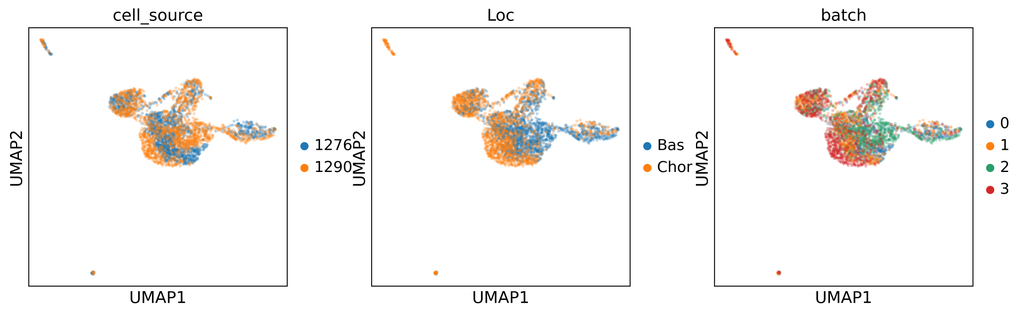

```python
sc.pl.umap(adata_basChor, color=['cell_source', 'Loc', 'batch'], alpha=0.3, size=25)
```

```python
#Save this data here:
adata_basChor.write_h5ad('./adata_basChor_preIntegration_May24.h5ad')
```

```python
#To reload and start from here I can do:
#adata_basChor = sc.read('adata_basChor_preIntegration_May24.h5ad')
```

```python
scvi.model.SCVI.setup_anndata(
    adata_basChor,
    layer="counts",
    categorical_covariate_keys=["batch","cell_source"])
```

```
An NVIDIA GPU may be present on this machine, but a CUDA-enabled jaxlib is not installed. Falling back to cpu.
```

```python
model_basChor_May24 = scvi.model.SCVI(adata_basChor)
```

```python
model_basChor_May24.train()
```

```
GPU available: True (cuda), used: True
TPU available: False, using: 0 TPU cores
IPU available: False, using: 0 IPUs
HPU available: False, using: 0 HPUs
You are using a CUDA device ('NVIDIA GeForce RTX 3060') that has Tensor Cores. To properly utilize them, you should set `torch.set_float32_matmul_precision('medium' | 'high')` which will trade-off precision for performance. For more details, read https://pytorch.org/docs/stable/generated/torch.set_f…
LOCAL_RANK: 0 - CUDA_VISIBLE_DEVICES: [0]
```

```
`Trainer.fit` stopped: `max_epochs=400` reached.
```

```python
#saving the model
model_basChor_May24.save("model_for_basChor_only_May24/")
```

```python
#if I wanted to load the model
model_basChor_May24 = scvi.model.SCVI.load("model_for_basChor_only_May24/", adata=adata_basChor)
```

```
INFO     File model_for_basChor_only_May24/model.pt already downloaded
```

```
An NVIDIA GPU may be present on this machine, but a CUDA-enabled jaxlib is not installed. Falling back to cpu.
```

```python
#get the model outputs
latent_basChor = model_basChor_May24.get_latent_representation()
```

```python
adata_basChor.obsm["X_scVI"] = latent_basChor
```

```python
# run PCA then generate UMAP plots
sc.tl.pca(adata_basChor)
sc.pp.neighbors(adata_basChor, n_pcs=30, n_neighbors=20)
sc.tl.umap(adata_basChor, min_dist=0.3)
```

```
computing PCA
    with n_comps=50
    finished (0:00:00)
computing neighbors
    using 'X_pca' with n_pcs = 30
    finished: added to `.uns['neighbors']`
    `.obsp['distances']`, distances for each pair of neighbors
    `.obsp['connectivities']`, weighted adjacency matrix (0:00:01)
computing UMAP
    finished: added
    'X_umap', UMAP coordinates (adata.obsm) (0:00:02)
```

```
WARNING: saving figure to file figures/umapbatch_preIntegration_basChor_only_reint.svg
```

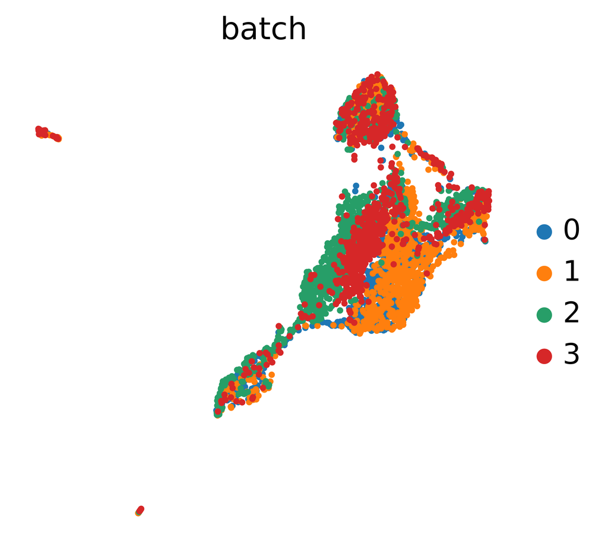

```
WARNING: saving figure to file figures/umapcellSource_preIntegration_basChor_only_reint.svg
```

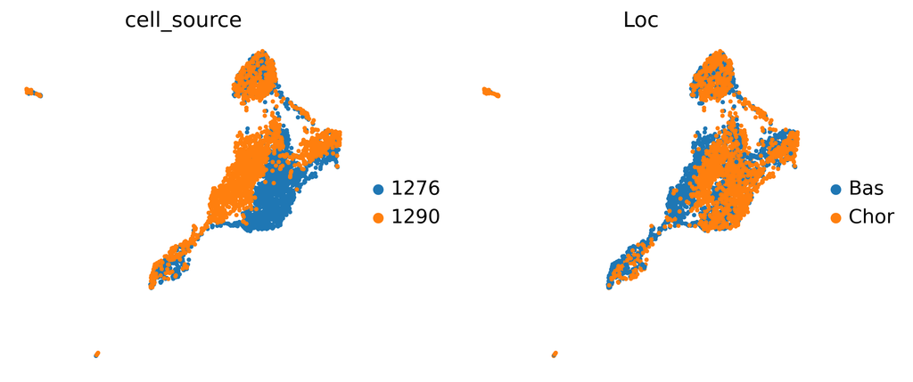

```python
sc.pl.umap(
    adata_basChor,
    color=["batch"],
    frameon=False)
sc.pl.umap(
    adata_basChor,
    color=["cell_source","Loc"],
    ncols=2,
    frameon=False)
```

```python
# use scVI latent space for UMAP generation
sc.pp.neighbors(adata_basChor, use_rep="X_scVI")
sc.tl.umap(adata_basChor, min_dist=0.3)
```

```
computing neighbors
    finished: added to `.uns['neighbors']`
    `.obsp['distances']`, distances for each pair of neighbors
    `.obsp['connectivities']`, weighted adjacency matrix (0:00:00)
computing UMAP
    finished: added
    'X_umap', UMAP coordinates (adata.obsm) (0:00:02)
```

```
WARNING: saving figure to file figures/umapbatch_postIntegration_basChor_only_reint.svg
```

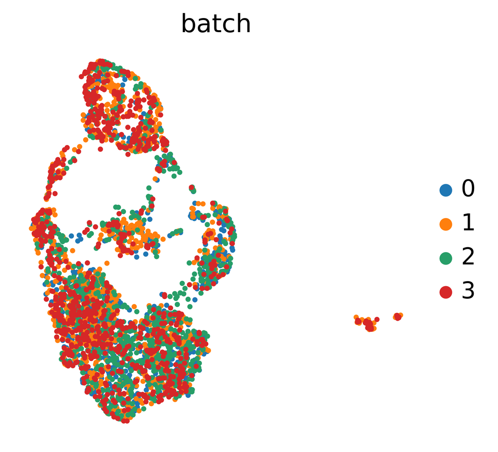

```
WARNING: saving figure to file figures/umapcellSource_Loc_postIntegration_basChor_only_reint.svg
```

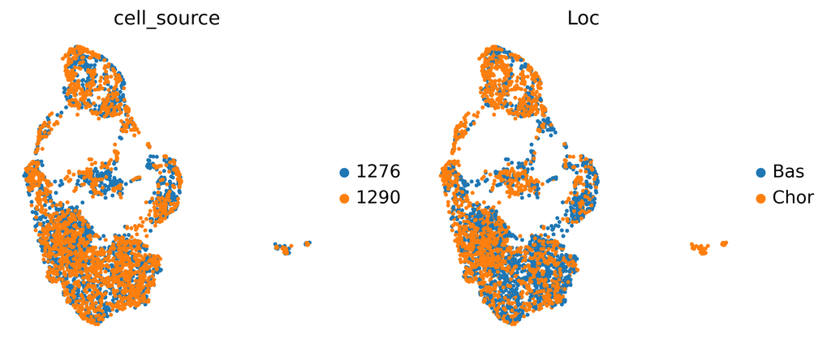

```python
sc.pl.umap(
    adata_basChor,
    color=["batch"],
    frameon=False)
sc.pl.umap(
    adata_basChor,
    color=["cell_source","Loc"],
    ncols=2,
    frameon=False)
```

```python
#Going to save the data here:
adata_basChor.write_h5ad('./adata_basChor_postIntegration_Dec24.h5ad')
```

Now I need to recluster and annotate

# Clustering and Annotation

```python
#Reload the data
adata_basChor = sc.read('adata_basChor_postIntegration_Dec24.h5ad')
```

# Clustering and Annotation with resolution of 0.5

```
running Leiden clustering
    finished: found 10 clusters and added
    'leiden_r0_5', the cluster labels (adata.obs, categorical) (0:00:00)
WARNING: saving figure to file figures/umapall_basChor_clustered_r0_5_sub2_tab20.svg
```

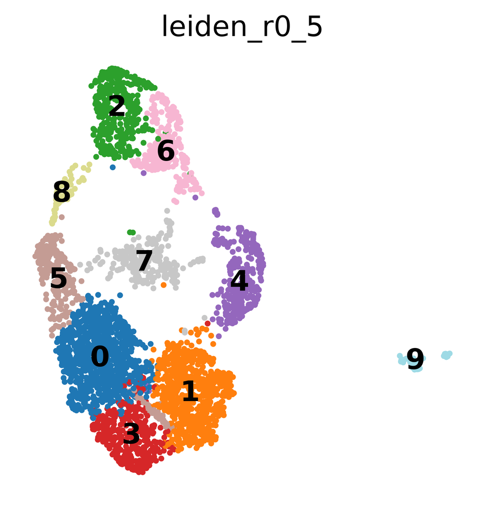

```python
#Just want to export the umap with the same palette
sc.tl.leiden(adata_basChor, resolution=0.5, key_added='leiden_r0_5')
sc.pl.umap(adata_basChor, color=['leiden_r0_5'], palette='tab20', frameon=False,legend_loc='on data', save='all_basChor_clustered_r0_5_FigS6b.svg')
```

## Marker gene expression

```
WARNING: dendrogram data not found (using key=dendrogram_leiden_r0_5). Running `sc.tl.dendrogram` with default parameters. For fine tuning it is recommended to run `sc.tl.dendrogram` independently.
    using 'X_pca' with n_pcs = 50
Storing dendrogram info using `.uns['dendrogram_leiden_r0_5']`
WARNING: saving figure to file figures/dotplot_all_basChor_data_dotplot_r0_5_sub2.svg
```

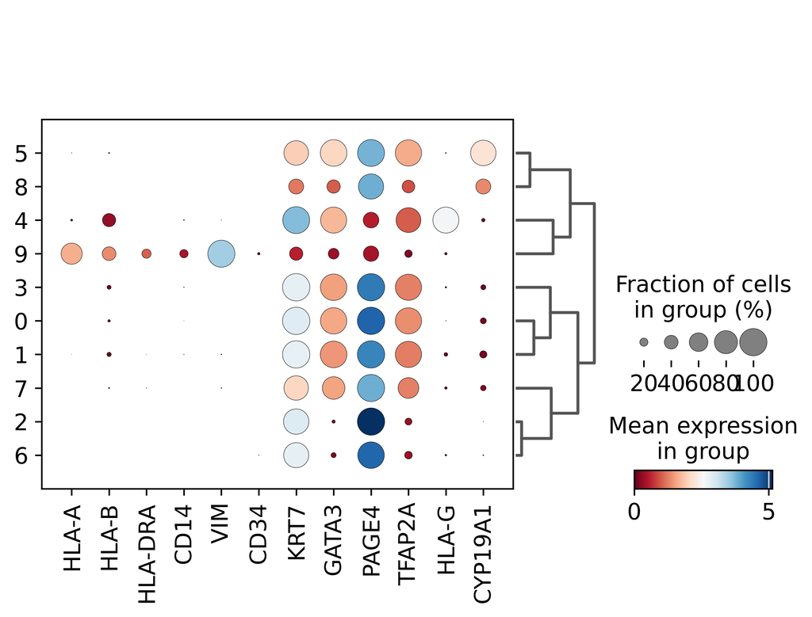

```python
sc.pl.dotplot(adata_basChor, var_names=['HLA-A','HLA-B','HLA-DRA','CD14','VIM','CD34','KRT7','GATA3','PAGE4','TFAP2A','HLA-G','CYP19A1'],
              groupby="leiden_r0_5",dendrogram=True,cmap='RdBu',save='all_basChor_data_dotplot_r0_5_FigS6b.svg')
```

Based on these markers we will get rid of cluster 9 in the 0.5 resolution

```python
adata_basChor = adata_basChor[adata_basChor.obs['leiden_r0_5'].isin(['0','1','2','3','4','5','6','7','8'])]
```

[output not shown]

Annotate clusters with marker genes

```
    using 'X_pca' with n_pcs = 50
Storing dendrogram info using `.uns['dendrogram_leiden_r0_5']`
WARNING: saving figure to file figures/dotplot_basChor_troph_only_marker_expression_r0_5_sub2.svg
```

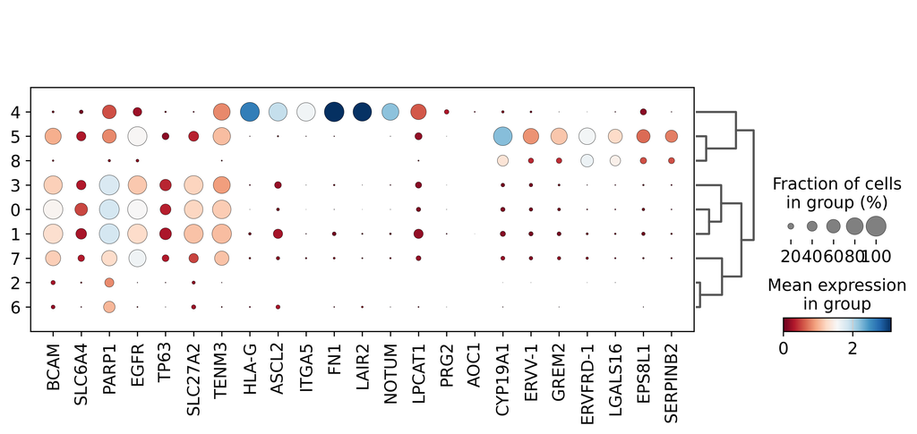

```python
sc.tl.dendrogram(adata_basChor, groupby='leiden_r0_5')
sc.pl.dotplot(adata_basChor, var_names=['BCAM','SLC6A4','PARP1','EGFR','TP63','SLC27A2','TENM3','HLA-G','ASCL2','ITGA5','FN1','LAIR2','NOTUM','LPCAT1','PRG2','AOC1',
                                        'CYP19A1','ERVV-1','GREM2','ERVFRD-1','LGALS16','EPS8L1','SERPINB2'], groupby="leiden_r0_5",dendrogram=True,cmap='RdBu',
              save='basChor_troph_only_marker_expression_r0_5_FigS6c.svg')
```

Using the markers, clusters were annotated using broad trophoblast categories

```
WARNING: saving figure to file figures/umapbasChor_troph_only_umap_reclustered_named_res0_5_sub2.svg
```

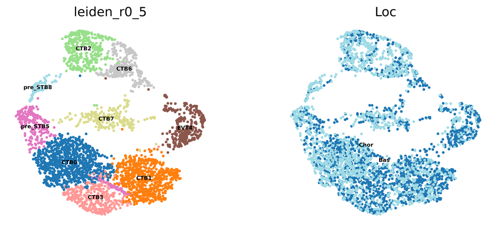

```python
cluster_names = ['CTB0', 'CTB1', 'CTB2', 'CTB3', 'EVT4','pre_STB5','CTB6','CTB7','pre_STB8']
adata_basChor.rename_categories('leiden_r0_5', cluster_names)
sc.pl.umap(adata_basChor, color=['leiden_r0_5','Loc'], frameon=False, palette='tab20',legend_fontsize=6,legend_loc='on data',
           save='basChor_troph_only_umap_reclustered_named_res0_5_Fig3b.svg')
```

```python
pd.crosstab(adata_basChor.obs['Loc'], adata_basChor.obs['leiden_r0_5'])
```

| leiden_r0_5 Loc | CTB0 | CTB1 | CTB2 | CTB3 | EVT4 | pre_STB5 | CTB6 | CTB7 | pre_STB8 |
| --- | --- | --- | --- | --- | --- | --- | --- | --- | --- |
| Bas | 410 | 429 | 106 | 218 | 223 | 113 | 95 | 118 | 15 |
| Chor | 509 | 275 | 265 | 141 | 101 | 164 | 178 | 142 | 63 |

```
WARNING: saving figure to file figures/dendrogramadata_basChor_dendrogram_named_res0_5_sub2.svg
```

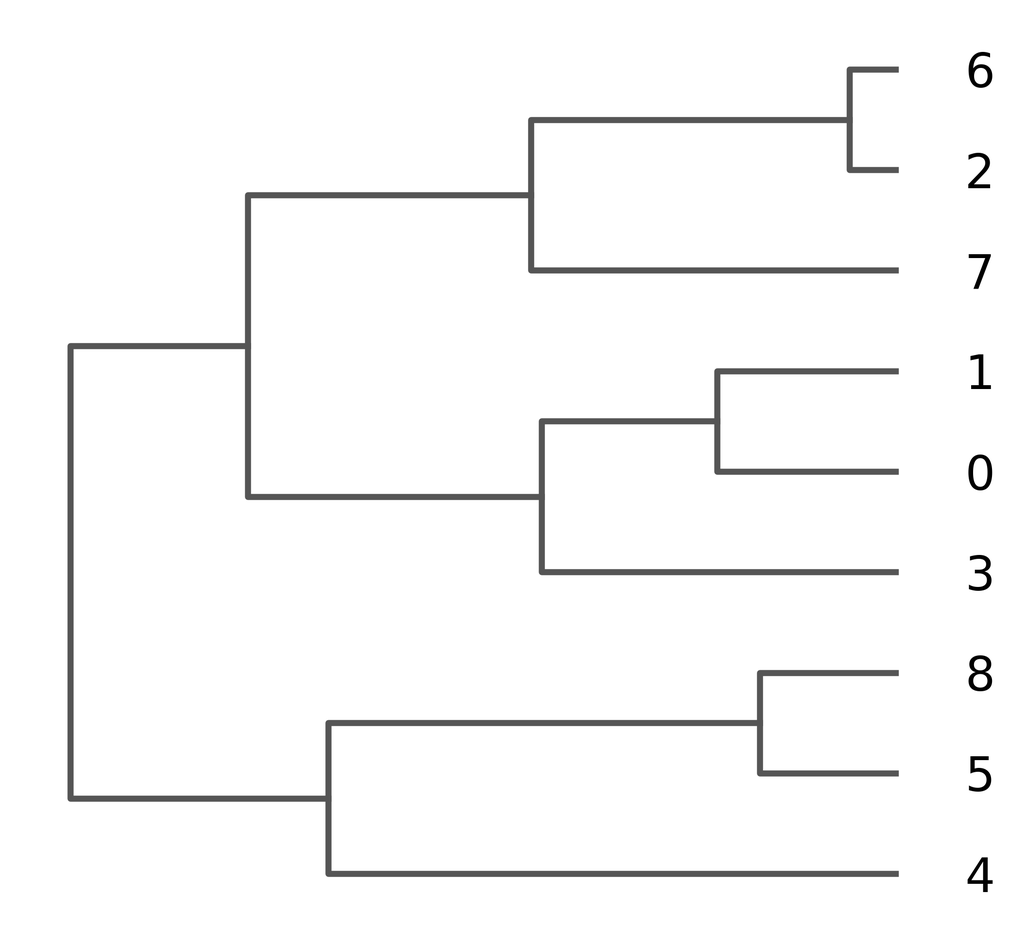

```python
sc.pl.dendrogram(adata_basChor,groupby='leiden_r0_5',orientation='left',save='adata_basChor_dendrogram_named_res0_5_Fig3b.svg')
```

```
WARNING: saving figure to file figures/umapinitial_state_expression_HMMR_TROAP_BasChor_sub2.svg
```

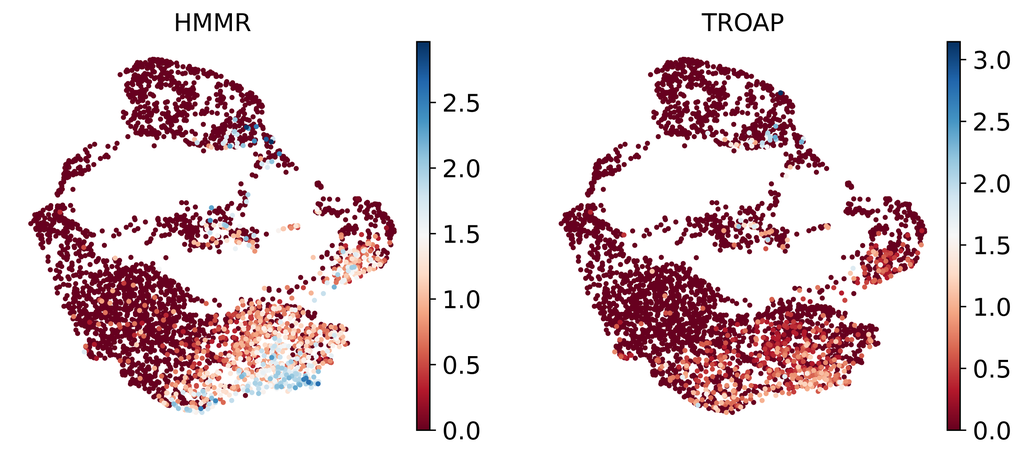

```python
sc.pl.umap(adata_basChor, color=['HMMR','TROAP'], palette='tab20',cmap='RdBu', frameon=False,legend_loc='on data', save='initial_state_expression_HMMR_TROAP_BasChor_FigS8a.svg')
```

```
WARNING: saving figure to file figures/umapinitial_state_expression_MXD3_CENPA_BasChor_sub2.svg
```

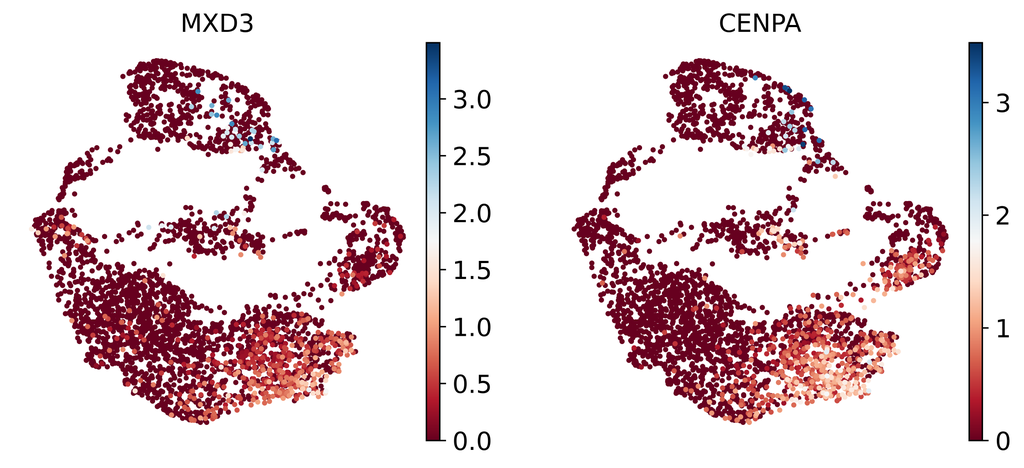

```python
sc.pl.umap(adata_basChor, color=['MXD3','CENPA'], palette='tab20',cmap='RdBu', frameon=False,legend_loc='on data', save='initial_state_expression_MXD3_CENPA_BasChor_FigS8b.svg')
```

Now I want to look at the WTA data in this dataset

```python
adata_basChor = sc.read('adata_basChor_clustered_named_Dec24.h5ad')
```

Now I would like to see what the statistically sig genes (log2FC > 1 and pval < 0.05) from the CP and BP genes from the WTA look like in the 0.5 resolution clustering

```
computing score 'CP_UpReg_Genes'
WARNING: genes are not in var_names and ignored: Index(['ART1', 'TBC1D28', 'CCDC184', 'UGT2B10', 'KRT5', 'GH1', 'OR4E1', 'SBSN',
       'SMIM23', 'B4GALNT1', 'GZMH', 'NXF2'],
      dtype='object')
    finished: added
    'CP_UpReg_Genes', score of gene set (adata.obs).
    1094 total control genes are used. (0:00:00)
computing score 'BP_UpReg_Genes'
WARNING: genes are not in var_names and ignored: Index(['H3C12', 'H1-1', 'H4C9'], dtype='object')
    finished: added
    'BP_UpReg_Genes', score of gene set (adata.obs).
    798 total control genes are used. (0:00:00)
```

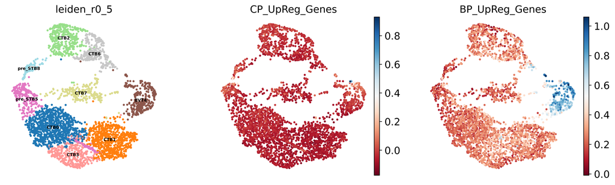

```python
#Score cell cycle and visualize the effect:
score_lfc_genes = pd.read_csv('qval_0_05_log2fc_1_bp_cp_list.csv')
cp_genes = score_lfc_genes['CP_Upreg'].dropna()
bp_genes = score_lfc_genes['BP_Upreg'].dropna()

sc.tl.score_genes(adata_basChor, cp_genes, score_name='CP_UpReg_Genes')
sc.tl.score_genes(adata_basChor, bp_genes, score_name='BP_UpReg_Genes')
sc.pl.umap(adata_basChor, color=['leiden_r0_5','CP_UpReg_Genes','BP_UpReg_Genes'], frameon=False, palette='tab20',legend_fontsize=6,legend_loc='on data',cmap='RdBu')
```

```
WARNING: saving figure to file figures/violinviolin_plot_BP_UpReg_genes_in_bas_chor.svg
```

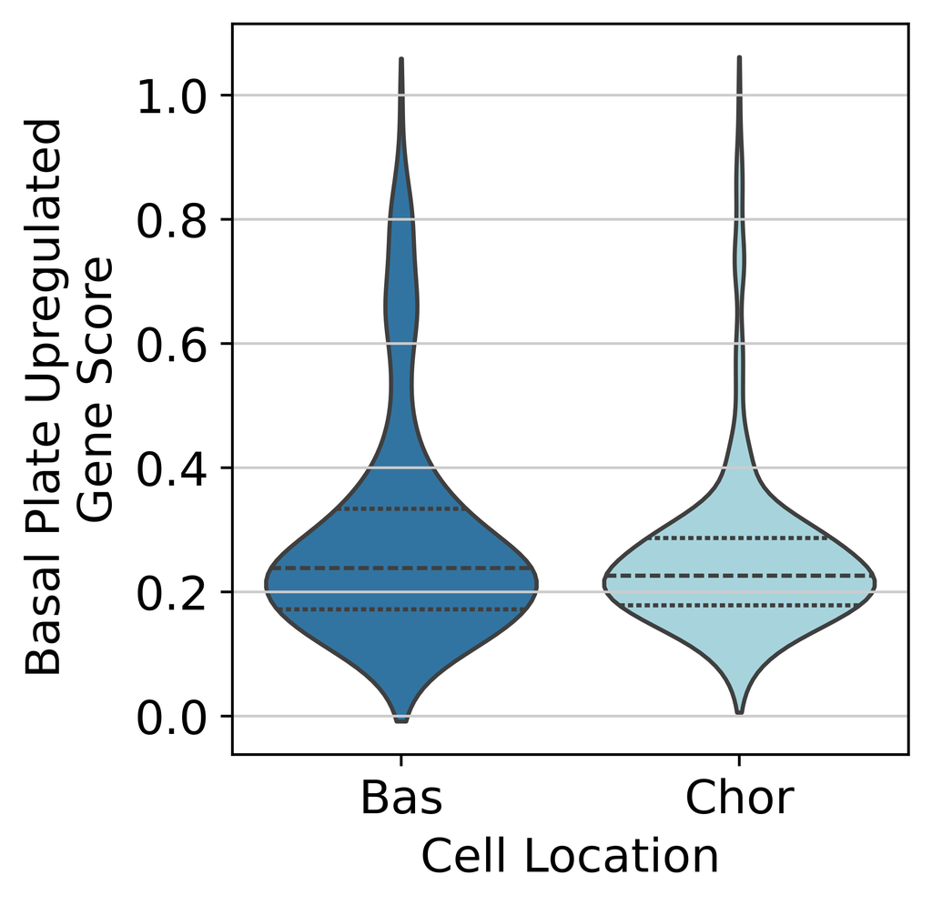

```python
sc.pl.violin(adata_basChor, keys="BP_UpReg_Genes", groupby="Loc", order=["Bas", "Chor"],ylabel="Basal Plate Upregulated \nGene Score",xlabel="Cell Location",
             inner="quartile",stripplot=False,save="violin_plot_BP_UpReg_genes_in_bas_chor_FigS7.svg")
```

```
WARNING: saving figure to file figures/violinviolin_plot_CP_UpReg_genes_in_bas_chor.svg
```

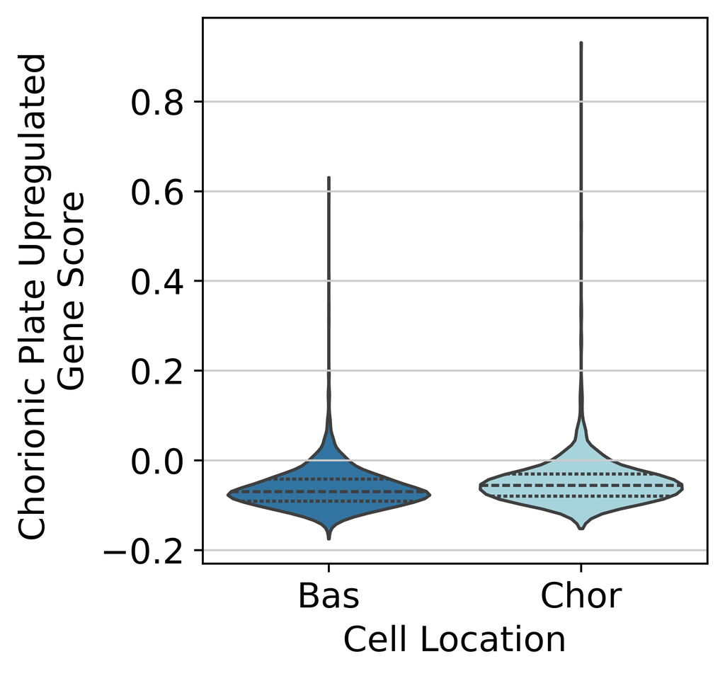

```python
sc.pl.violin(adata_basChor, keys="CP_UpReg_Genes", groupby="Loc", order=["Bas", "Chor"],ylabel="Chorionic Plate Upregulated \nGene Score",xlabel="Cell Location",
             stripplot=False,inner="quartile",save="violin_plot_CP_UpReg_genes_in_bas_chor_FigS7b.svg")
```

```python
#If I do a statistical test using the score
from scipy.stats import ranksums

# Get scores for Bas and Chor
score_basal_bp = adata_basChor.obs.loc[adata_basChor.obs["Loc"] == "Bas", "BP_UpReg_Genes"]
score_chorionic_bp = adata_basChor.obs.loc[adata_basChor.obs["Loc"] == "Chor", "BP_UpReg_Genes"]

# Perform Wilcoxon test
stat, p_value = ranksums(score_basal_bp, score_chorionic_bp)

print(f"Wilcoxon rank-sum test between basal plate cells and chorionic plate cells for BP upreg genes:\nStatistic={stat}, p-value={p_value}")
```

```
Wilcoxon rank-sum test between basal plate cells and chorionic plate cells for BP upreg genes:
Statistic=3.406075209563129, p-value=0.0006590402119561157
```

```python
#If I do a statistical test using the score
from scipy.stats import ranksums

# Get scores for Bas and Chor
score_basal_cp = adata_basChor.obs.loc[adata_basChor.obs["Loc"] == "Bas", "CP_UpReg_Genes"]
score_chorionic_cp = adata_basChor.obs.loc[adata_basChor.obs["Loc"] == "Chor", "CP_UpReg_Genes"]

# Perform Wilcoxon test
stat, p_value = ranksums(score_basal_cp, score_chorionic_cp)

print(f"Wilcoxon rank-sum test between basal plate cells and chorionic plate cells for BP upreg genes:\nStatistic={stat}, p-value={p_value}")
```

```
Wilcoxon rank-sum test between basal plate cells and chorionic plate cells for BP upreg genes:
Statistic=-9.950128665917733, p-value=2.518573722824191e-23
```

```python
#save the data here
adata_basChor.write_h5ad('./adata_basChor_clustered_named_Dec24.h5ad')
```

# Initial State expression using CTB1 initial state cells from 6wk/13wk combined data

```python
#reload the data here
adata_basChor = sc.read('adata_basChor_clustered_named_Dec24.h5ad')
```

```python
sig_genes_6_13wk = pd.read_csv('6wk_13wk_combo_noTSC_initial_state_vs_all_True_only_sig_list.csv')
sig_gene_6_13wk_list = sig_genes_6_13wk.iloc[:,0].tolist()
```

```
computing score '6wk_13wk_sig_genes'
    finished: added
    '6wk_13wk_sig_genes', score of gene set (adata.obs).
    584 total control genes are used. (0:00:00)
WARNING: saving figure to file figures/umapinitial_state_scoring_from_6wk_13wk_dataset_umap.svg
```

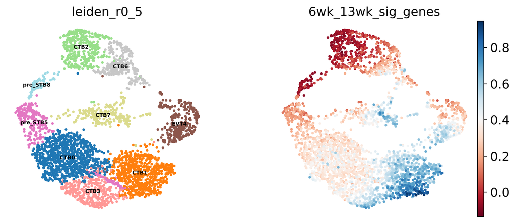

```python
sc.tl.score_genes(adata_basChor, sig_gene_6_13wk_list, score_name='6wk_13wk_sig_genes')
sc.pl.umap(adata_basChor, color=['leiden_r0_5','6wk_13wk_sig_genes'], frameon=False, palette='tab20',legend_fontsize=6,legend_loc='on data',cmap='RdBu',
           save='initial_state_scoring_from_6wk_13wk_dataset_umap_Fig3d.svg')
```

```
WARNING: saving figure to file figures/violinvioloin_plot_initial_state_genes_in_bas_chor.svg
```

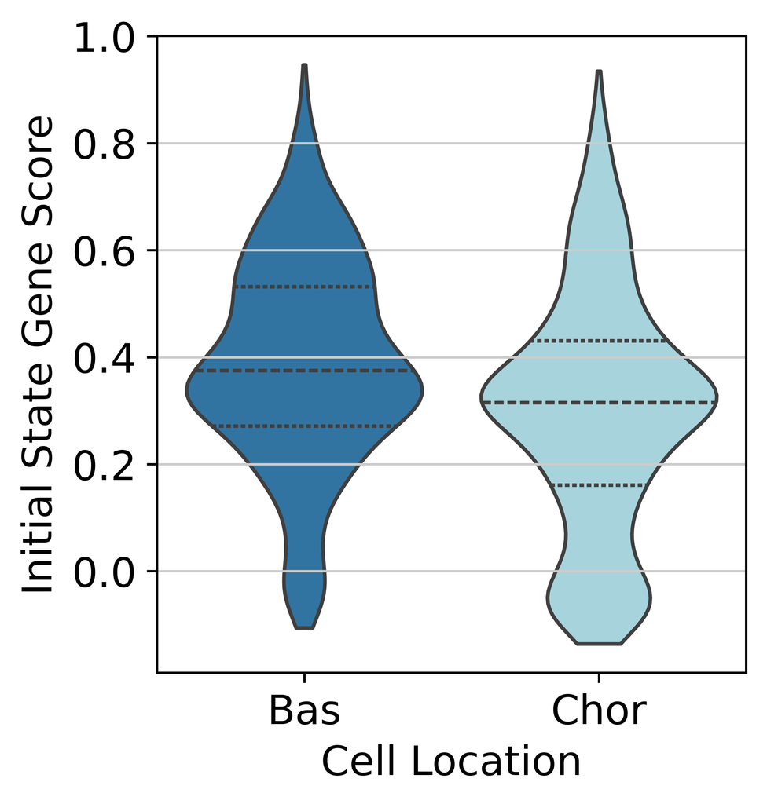

```python
sc.pl.violin(adata_basChor, keys="6wk_13wk_sig_genes", groupby="Loc", order=["Bas", "Chor"],ylabel="Initial State Gene Score",xlabel="Cell Location",
             stripplot=False,inner='quartile', save='violoin_plot_initial_state_genes_in_bas_chor_Fig3e.svg')
```

```python
#If I do a statistical test using the score
from scipy.stats import ranksums

# Get scores for Bas and Chor
score_basal_initial = adata_basChor.obs.loc[adata_basChor.obs["Loc"] == "Bas", "6wk_13wk_sig_genes"]
score_chorionic_initial = adata_basChor.obs.loc[adata_basChor.obs["Loc"] == "Chor", "6wk_13wk_sig_genes"]

# Perform Wilcoxon test
stat, p_value = ranksums(score_basal_initial, score_chorionic_initial)

print(f"Wilcoxon rank-sum test between basal plate cells and chorionic plate cells for initial state significantly upregulated genes:\nStatistic={stat}, p-value={p_value}")
```

```
Wilcoxon rank-sum test between basal plate cells and chorionic plate cells for initial state significantly upregulated genes:
Statistic=12.062214381374583, p-value=1.672253837531201e-33
```

```python
#save the data here
adata_basChor.write_h5ad('./adata_basChor_Feb25.h5ad')
```

```python
#To reload the data...
adata_basChor = sc.read('adata_basChor_Feb25.h5ad')
```